# workshop_3

2024-06-24

# Setup

## Library check-out

```r
library(tidyverse)
```

```r
library(ggplot2)
library(ggbeeswarm)
library(wesanderson)
```

## Colour palettes

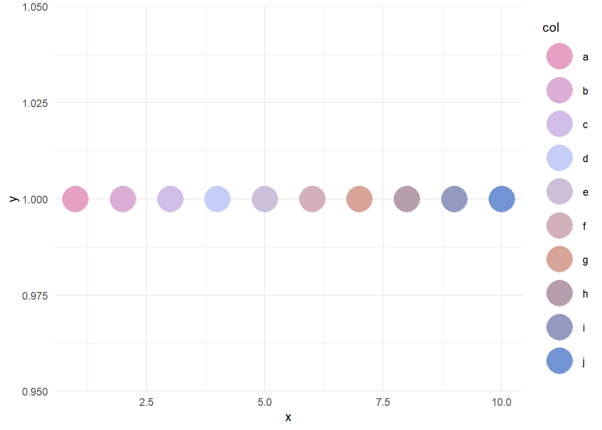

```r
theme_set(theme_minimal())

#Color palette code
grand_budapest2_palette <- wes_palette("GrandBudapest2", n = 10, type = "continuous") #this specifices which palette from the package, the number of colors (in this case 10), and that we need a continuous colour ramp as opposed to discrete

df <- data.frame(x=1:10, y=1, col=letters[1:10]) #create an empty dataframe

g <- ggplot(df, aes(x=x, y=y, color=col)) + geom_point(size=10) +
  scale_color_manual(values=wes_palette(10, name = "GrandBudapest2", type = "continuous")) #build a plot of the palette against your empty dataframe
g #view the colors
```

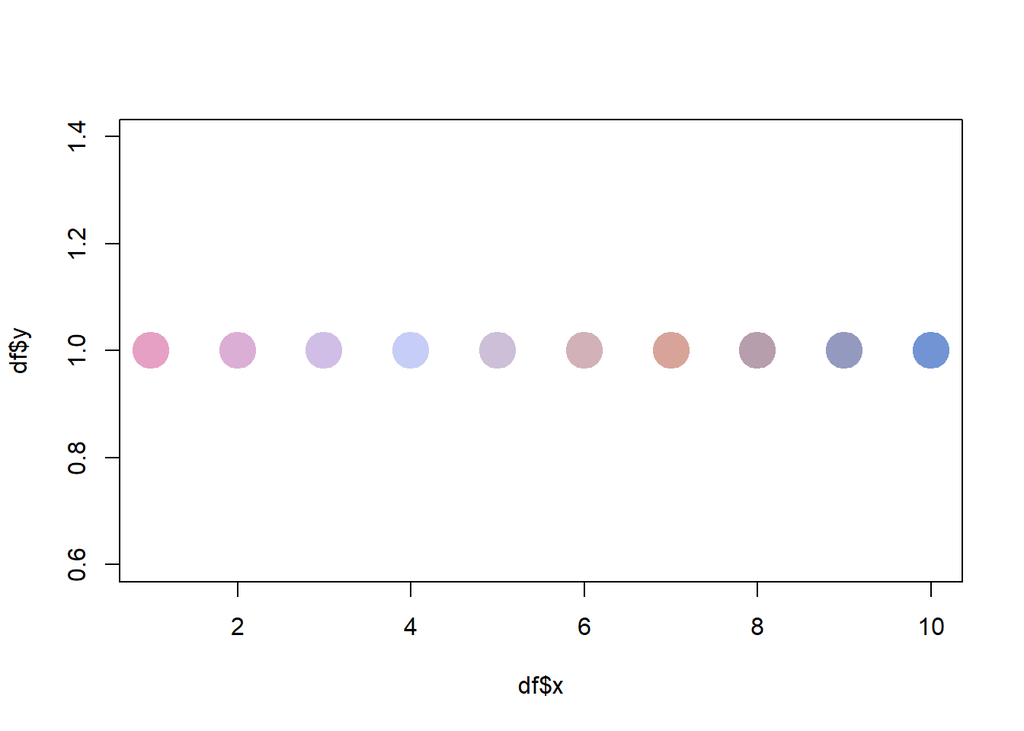

```r
#if you like them, proceed with the below steps to get the hex codes and then build the palette, calling hex codes to specific values in your actual datasets

colors <- ggplot_build(g)$data[[1]]$colour

plot(df$x, df$y, col=colors, pch=20, cex=5)
```

```r
colors[1:10]
```

```
##  [1] "#E6A0C4" "#DBAFD5" "#D0BEE6" "#C6CDF7" "#CCBFD7" "#D2B1B8" "#D8A499"
##  [8] "#B69EAC" "#9499C0" "#7294D4"
```

```r
# Manually assign the hex codes to create a custom stretched palette
site_palette <- c(
  "Clovelly Beach" = "#7294D4",
  "Coogee Beach" = "#9499C0",
  "Bondi Beach" = "#C6CDF7",
  "Malabar Beach" = "#CCBFD7",
  "South Maroubra \nRockpool" = "#DBAFD5",
  "Bronte Beach" = "#E6A0C4"
)


print(site_palette)
```

```
##            Clovelly Beach              Coogee Beach               Bondi Beach
##                 "#7294D4"                 "#9499C0"                 "#C6CDF7"
##             Malabar Beach South Maroubra \nRockpool              Bronte Beach
##                 "#CCBFD7"                 "#DBAFD5"                 "#E6A0C4"
```

#Bring in data

```r
# in case you don't have the cleaned data, run this
# cleanbeaches <- read.csv("C:/Users/izzyj/Downloads/data_bootcamp/RYouWithMe/cleanbeaches.csv")

# cleanbeaches_new <- cleanbeaches %>%
#  separate(date, c("day","month","year"), remove = FALSE) %>%
#  mutate(logbeachbugs = log(beachbugs)) %>%
#  mutate(beachbugsdiff = beachbugs - log(beachbugs)) %>%
#  mutate(buggier_all = beachbugs > mean(beachbugs, na.rm = TRUE)) %>%
#  group_by(site) %>%
#  mutate(buggier_site = beachbugs > mean(beachbugs, na.rm = TRUE))

# write.csv(cleanbeaches_new, "C:/Users/izzyj/Downloads/data_bootcamp/RYouWithMe/cleanbeaches_new.csv", row.names = FALSE)
```

Read in data

```r
plotbeaches <- read.csv("C:/Users/izzyj/Downloads/data_bootcamp/RYouWithMe/cleanbeaches_new.csv")
```

Check to make sure it’s what we want

```r
head(plotbeaches)
```

```
##   X.1 X          council           site beachbugs beach_id
## 1   1 1 Randwick Council Clovelly Beach        19       25
## 2   2 2 Randwick Council Clovelly Beach         3       25
## 3   3 3 Randwick Council Clovelly Beach         2       25
## 4   4 4 Randwick Council Clovelly Beach        13       25
## 5   5 5 Randwick Council Clovelly Beach         8       25
## 6   6 6 Randwick Council Clovelly Beach         7       25
##                      region longitude  latitude       date day month year
## 1 Sydney City Ocean Beaches  151.2675 -33.91449 02/01/2013   2     1 2013
## 2 Sydney City Ocean Beaches  151.2675 -33.91449 06/01/2013   6     1 2013
## 3 Sydney City Ocean Beaches  151.2675 -33.91449 12/01/2013  12     1 2013
## 4 Sydney City Ocean Beaches  151.2675 -33.91449 18/01/2013  18     1 2013
## 5 Sydney City Ocean Beaches  151.2675 -33.91449 30/01/2013  30     1 2013
## 6 Sydney City Ocean Beaches  151.2675 -33.91449 05/02/2013   5     2 2013
##   logbeachbugs beachbugsdiff buggier_all buggier_site
## 1    2.9444390     16.055561       FALSE         TRUE
## 2    1.0986123      1.901388       FALSE        FALSE
## 3    0.6931472      1.306853       FALSE        FALSE
## 4    2.5649494     10.435051       FALSE         TRUE
## 5    2.0794415      5.920558       FALSE        FALSE
## 6    1.9459101      5.054090       FALSE        FALSE
```

IF YOU HAVE UNWANTED COLUMNS (which can happen when reading and writing between R and Excel because of row identifiers), use this to drop the columns you don’t want

```r
plotbeaches <- plotbeaches[, !(names(plotbeaches) %in% c("X", "X.1"))]
```

BEFORE PLOTTING (unlike the tutorial), SET YOUR DATA TYPES.

```r
plotbeaches$council <- as.factor(plotbeaches$council )
plotbeaches$site <- as.factor(plotbeaches$site)
plotbeaches$beachbugs <- as.numeric(plotbeaches$beachbugs)
plotbeaches$beach_id <- as.factor(plotbeaches$beach_id)
plotbeaches$year <- as.factor(plotbeaches$year)
plotbeaches$month  <- as.factor(plotbeaches$month)
plotbeaches$day <- as.factor(plotbeaches$day)
plotbeaches$beachbugsdiff <- as.numeric(plotbeaches$beachbugsdiff)
plotbeaches$logbeachbugs <- as.numeric(plotbeaches$logbeachbugs)
```

# Plot across years

Jitter plots stagger or ‘jitter’ points apart so you can see all (or at least more) of the data points

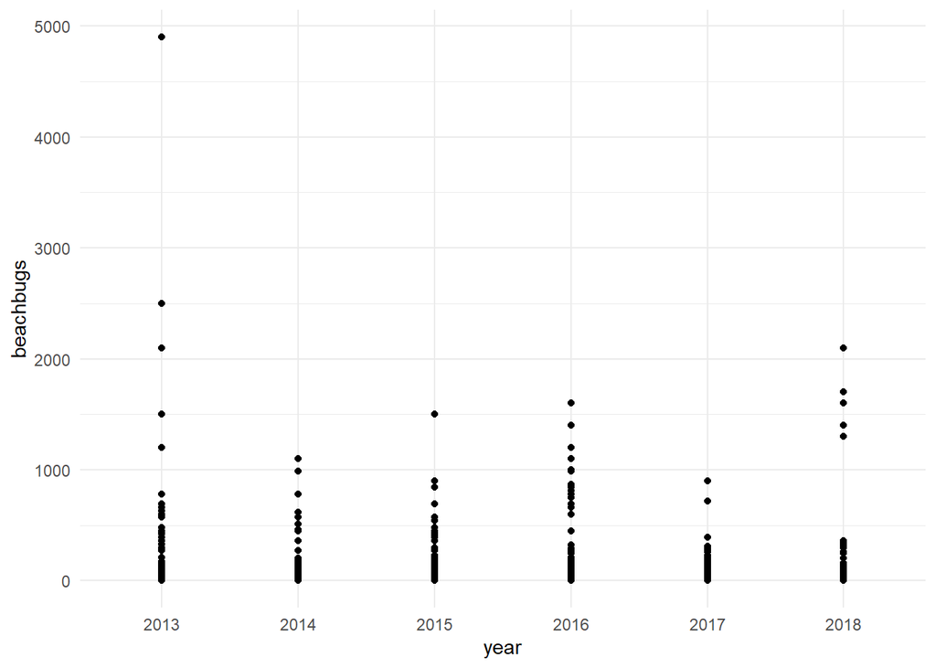

```r
plotbeaches %>%
  ggplot(aes(x = year, y = beachbugs)) +
  geom_point()
```

```r
plotbeaches %>%
  group_by(year) %>%
  summarise(obs = n())
```

```
## # A tibble: 6 × 2
##   year    obs
##   <fct> <int>
## 1 2013    602
## 2 2014    582
## 3 2015    627
## 4 2016    656
## 5 2017    673
## 6 2018    550
```

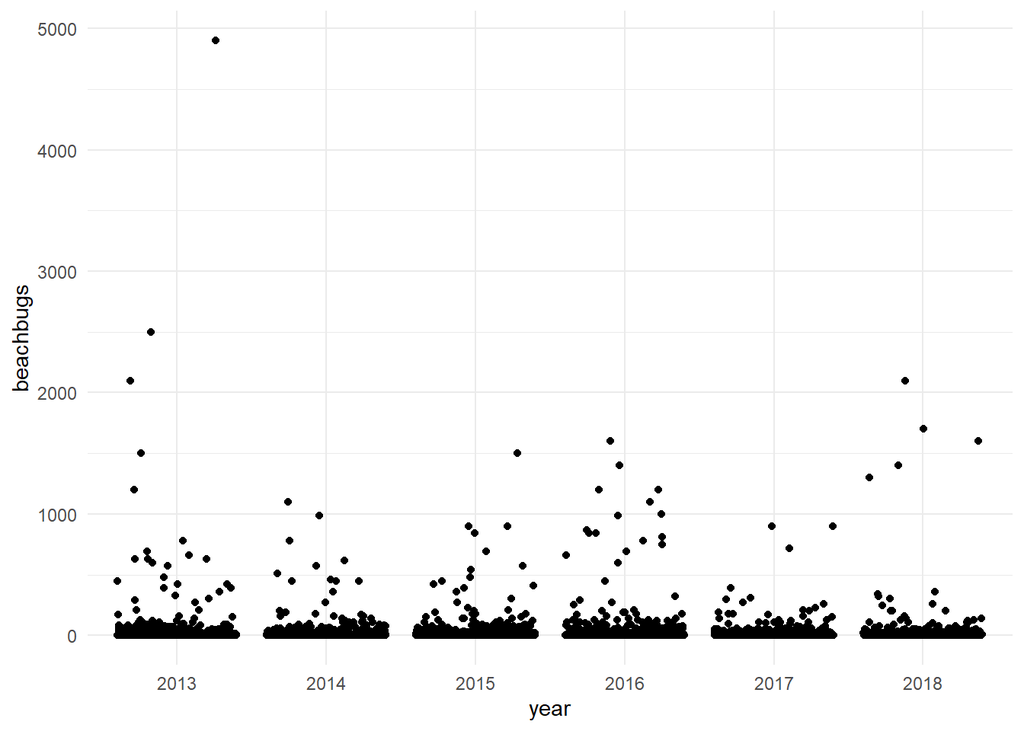

```r
plotbeaches %>%
  ggplot(aes(x = year, y = beachbugs)) +
  geom_jitter()
```

You might need to tweak the jitter. For example, to me this is a lot of jitter and makes it look a bit like variation over the course of the year. It’s not clear whether this is a jitter plot of a discrete variable or a scatter plot of a continuous variable. Quasirandom tries to correct for this.

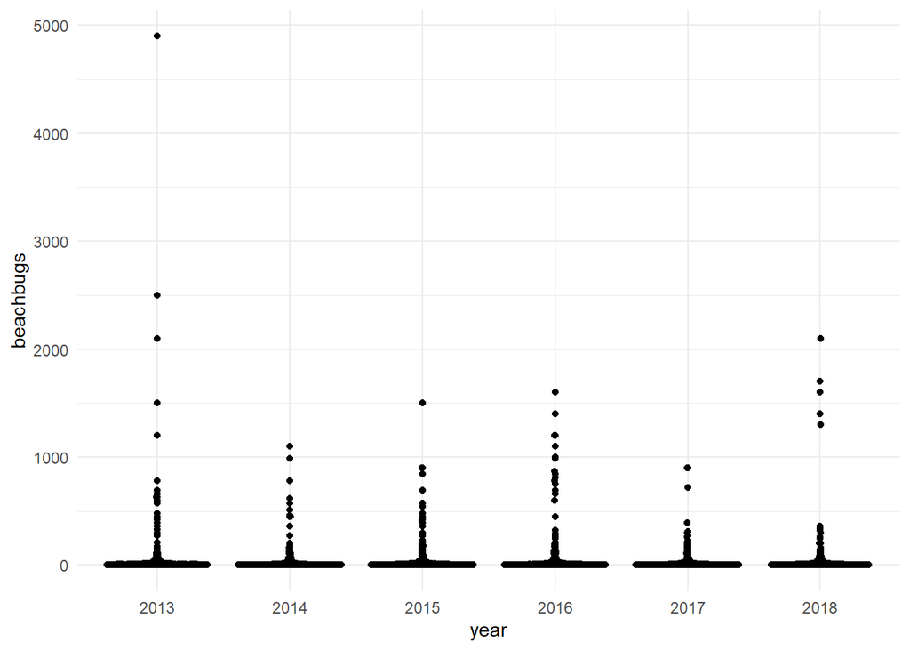

```r
plotbeaches %>%
  ggplot(aes(x = year, y = beachbugs)) +
  geom_quasirandom()
```

# Plot across sites

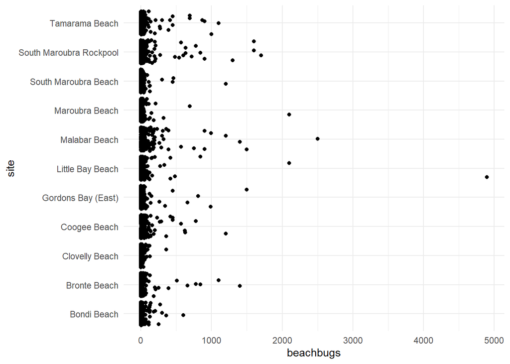

```r
plotbeaches %>%
  na.omit() %>%
  ggplot(aes(x = site, y = beachbugs)) +
  geom_jitter() +
  coord_flip()
```

They use coord_flip. You can also just flip the x and y calls OR if you want to keep the current x and y orientation, you can rotate the labels. I am going to move forward with my version.

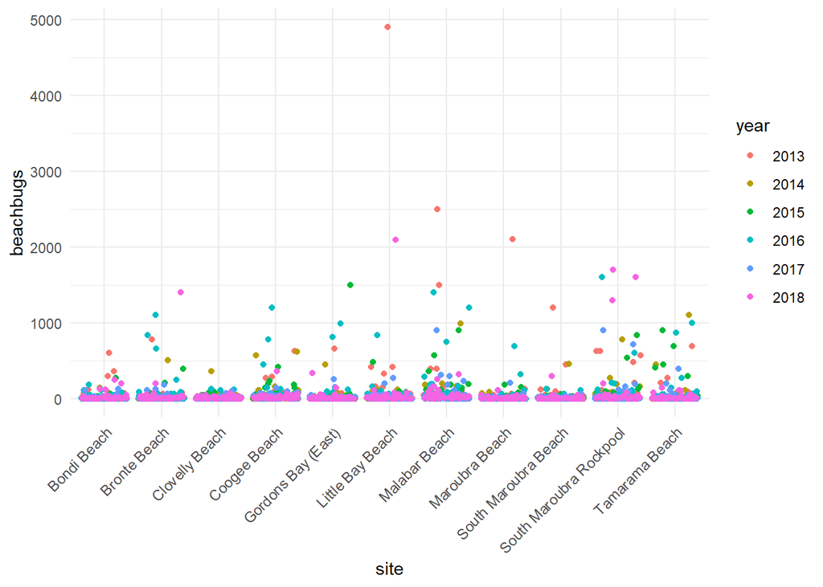

```r
plotbeaches %>%
  na.omit() %>%
  ggplot(aes(x = site, y = beachbugs, color = year)) +
  geom_jitter() +
  theme(axis.text.x = element_text(angle = 45, hjust = 1, vjust = 1, size = 9))
```

## Facet wrap

I also implement theme_minimal to get rid of that weird grey background.

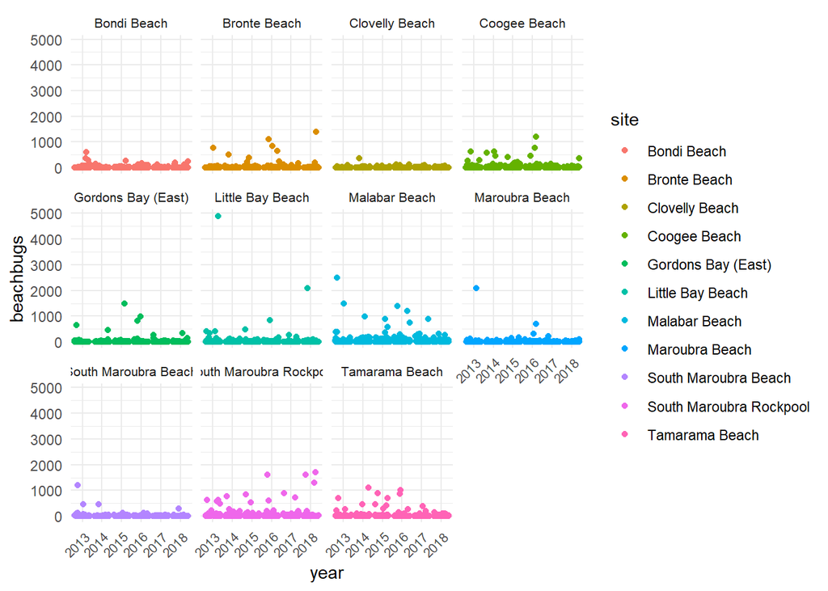

```r
plotbeaches %>%
  na.omit() %>%
  ggplot(aes(x = year, y = beachbugs, color = site)) +
  geom_jitter() +
  facet_wrap(~ site) +
  theme_minimal() +
  theme(axis.text.x = element_text(angle = 45, hjust = 1, vjust = 1, size = 8), strip.text = element_text(size = 8))
```

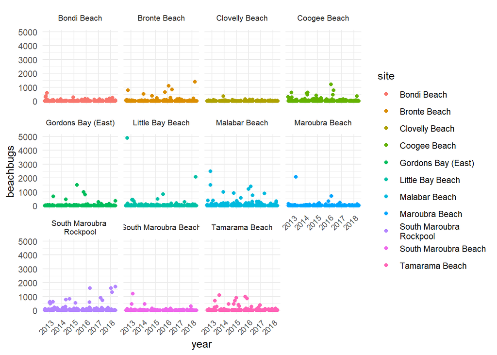

```r
plotbeaches$site <- as.character(plotbeaches$site) #this is necessary or else R will assign unspecified site names as factor levels i.e. numbers

#modify only the problematic site names
plotbeaches$site <- ifelse(plotbeaches$site == "South Maroubra Rockpool",
                           "South Maroubra \nRockpool",
                           plotbeaches$site)

#create the plot with facet wrap
plotbeaches %>%
  na.omit() %>%
  ggplot(aes(x = year, y = beachbugs, color = site)) +
  geom_jitter() +
  facet_wrap(~ site) +
  theme_minimal() +
  theme(axis.text.x = element_text(angle = 45, hjust = 1, vjust = 1, size = 8), strip.text = element_text(size = 8))
```

# Dplyr + ggplot

They use a simple ggsave method but it can get faulty when you work with a lot of plots and/or across different directories.

Instead, we are going to specify our plot as an ‘object’ in R called ‘p’, meaning it will appear in the Environment up in the right hand corner. To view it, you must use print(p). Save the dpi to 300 and the file as either a PNG or a TIFF (NOT A JPG/JPEG), this is publication standard.

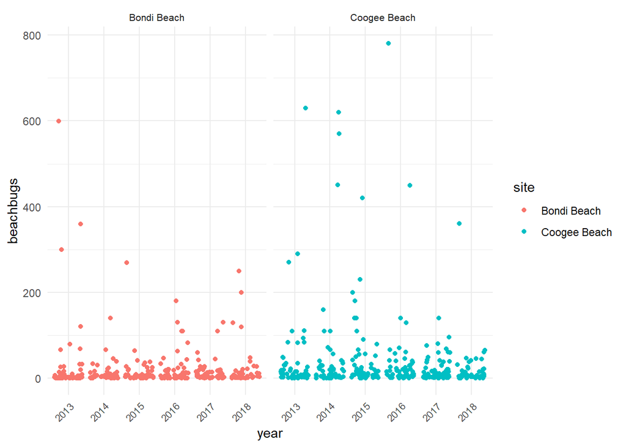

```r
p <- plotbeaches %>%
  na.omit() %>%
  filter(beachbugs < 1000) %>%
  filter(site %in% c("Coogee Beach", "Bondi Beach")) %>%
  ggplot(aes(x = year, y = beachbugs, color = site)) +
  geom_jitter() +
  facet_wrap(~ site) +
  theme_minimal() +
  theme(axis.text.x = element_text(angle = 45, hjust = 1, vjust = 1, size = 8), strip.text = element_text(size = 8))

print(p) #to view it and check it
```

```r
ggsave("C:/Users/izzyj/Downloads/data_bootcamp/RYouWithMe/coogeebondi.png", plot = p, width = 10, height = 6, dpi = 300)
```

# Violin plots

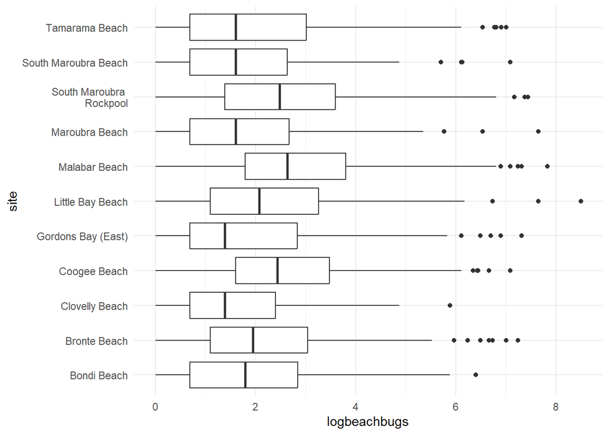

```r
plotbeaches %>%
  na.omit() %>%
  ggplot(aes(x = site, y = logbeachbugs)) +
  geom_boxplot() +
  coord_flip()
```

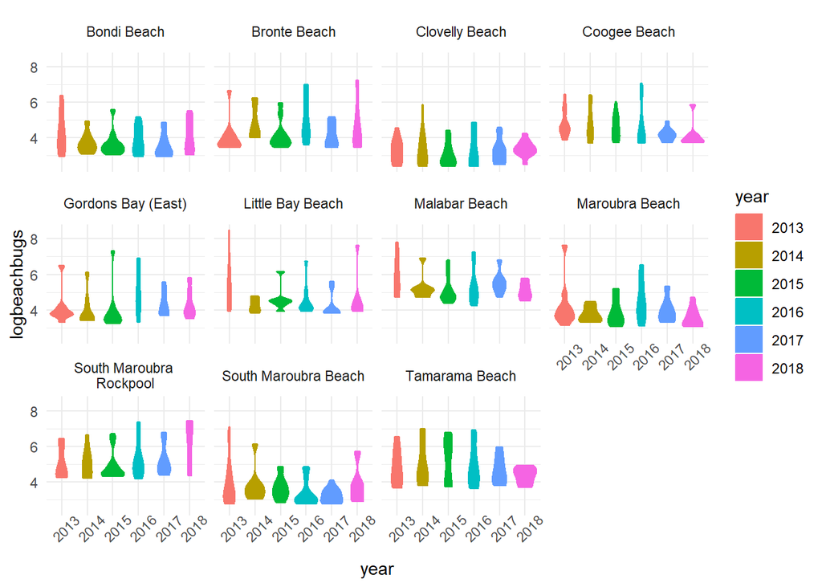

```r
plotbeaches %>%
  na.omit() %>%
  filter(buggier_site == TRUE) %>%
  ggplot(aes(x = year, y = logbeachbugs, color = year, fill = year)) +
  geom_violin() +
  facet_wrap(~ site) +
  theme_minimal() +
  theme(axis.text.x = element_text(angle = 45))
```

# Histograms

In this upcoming homework, you will learn more about histograms as part of data pre-processing for analysis as well.

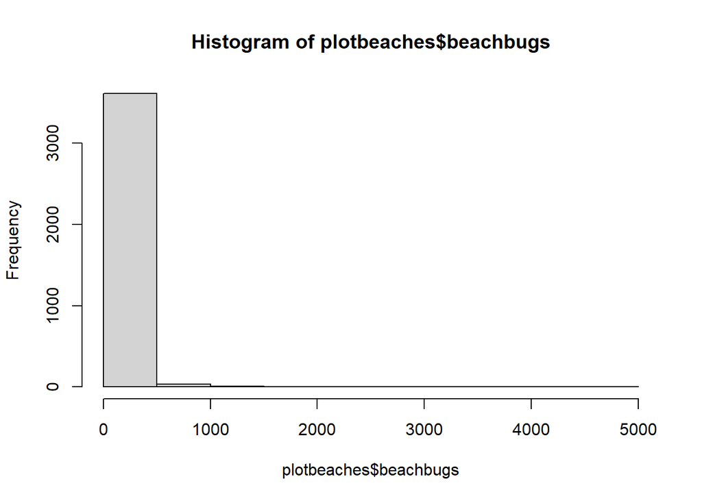

```r
hist(plotbeaches$beachbugs)
```

From the histogram, we see positive (right-)skew and possibly excess kurtosis. Skew refers to the direction of the tail, which in this case is to the right of the mean. Kurtosis is the peakedness, or concentration on and around the mean.

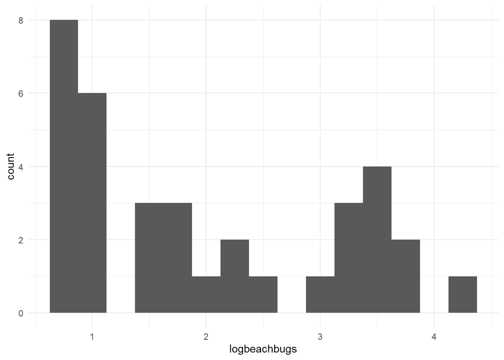

```r
plotbeaches %>%
  na.omit() %>%
  filter(site == "Clovelly Beach",
         year == "2018",
         logbeachbugs > 0) %>%
  ggplot(aes(x = logbeachbugs)) +
  geom_histogram(binwidth = 0.25)
```

# Combining plots

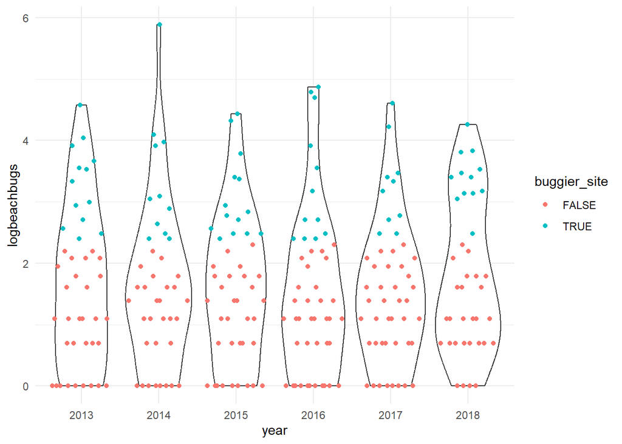

```r
plotbeaches %>%
  na.omit() %>%
  filter(site == "Clovelly Beach") %>%
  ggplot(aes(x = year, y = logbeachbugs)) +
  geom_violin() +
  geom_quasirandom(aes(color = buggier_site))
```

# Bars and columns

Sometimes, you do just need the bar graph. It is requested, you want to get a quick visual, or as I noted in slides: I think they can be useful to show TOTALS or AGGREGATES, including through stacking to illustrate proportionality e.g. how many people in each region rely on informal water resources, what % of their total water comes from which source. For averages or good statistical depictions of data, they are not good.

Geom_bar for frequency/count data

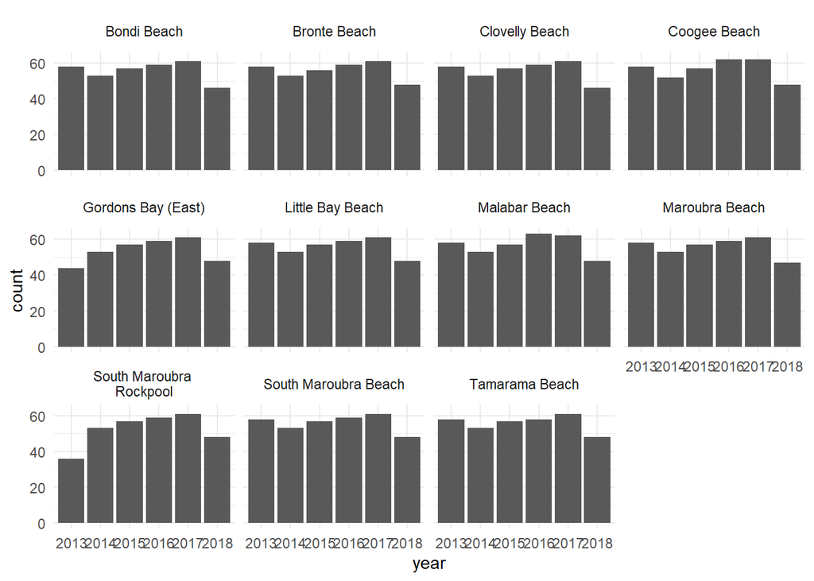

```r
plotbeaches %>%
  na.omit() %>%
  ggplot(aes(x = year)) +
  geom_bar() +
  facet_wrap(~ site)
```

Use geom_col for plotting summary stats (default of geom_col is to sum)

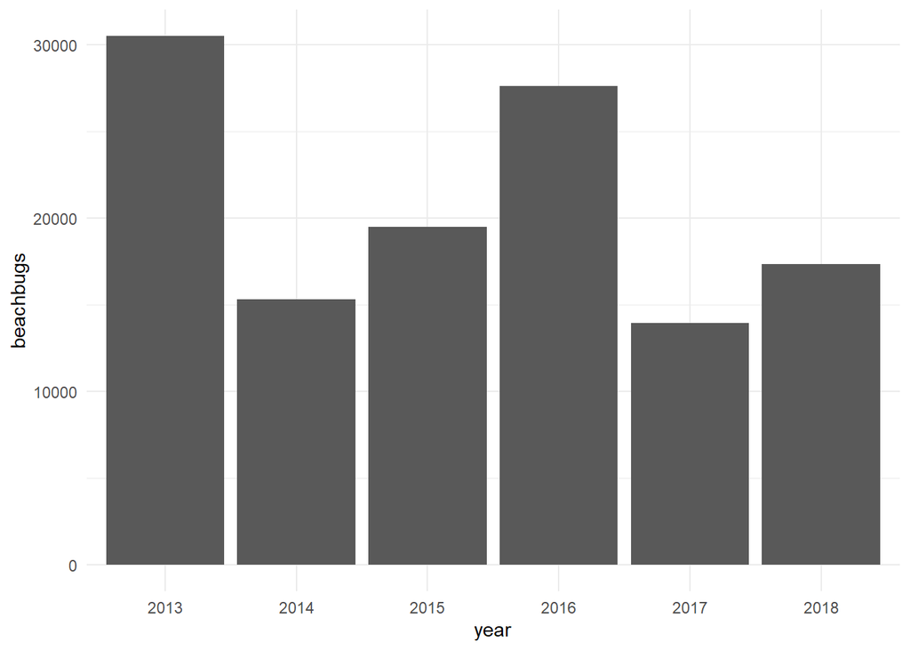

```r
plotbeaches %>%
  na.omit() %>%
  ggplot(aes(x = year, y = beachbugs)) +
  geom_col()
```

Get actual values

```r
plotbeaches %>%
  na.omit() %>%
  group_by(year) %>%
  summarise(totalbugs = sum(beachbugs))
```

```
## # A tibble: 6 × 2
##   year  totalbugs
##   <fct>     <dbl>
## 1 2013      30489
## 2 2014      15319
## 3 2015      19508
## 4 2016      27611
## 5 2017      13945
## 6 2018      17327
```

I do these steps separately…

```r
#summarize the data by year
summarized_data <- plotbeaches %>%
  na.omit() %>%
  group_by(year) %>%
  summarise(mean = mean(beachbugs),
            sd = sd(beachbugs),
            n = n(),
            stderr = sd/sqrt(n))

#check it out
print(summarized_data)
```

```
## # A tibble: 6 × 5
##   year   mean    sd     n stderr
##   <fct> <dbl> <dbl> <int>  <dbl>
## 1 2013   50.6 266.    602  10.8
## 2 2014   26.3  92.3   582   3.83
## 3 2015   31.2 106.    626   4.25
## 4 2016   42.2 157.    655   6.12
## 5 2017   20.7  67.3   673   2.59
## 6 2018   33.1 164.    523   7.15
```

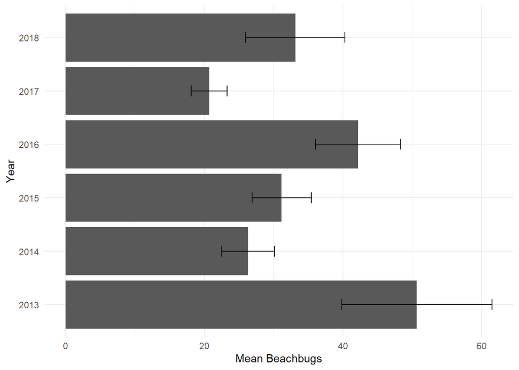

```r
#create the plot
plot <- ggplot(summarized_data, aes(x = year, y = mean)) +
  geom_col() +
  coord_flip() +
  geom_errorbar(aes(ymin = mean - stderr, ymax = mean + stderr), width = 0.2) +
  theme_minimal() +
  labs(y = "Mean Beachbugs", x = "Year")

#check it out
print(plot)
```

```r
#saved
ggsave("C:/Users/izzyj/Downloads/data_bootcamp/RYouWithMe/errorbars.png", plot = plot, width = 10, height = 6, dpi = 300)
```

# Regression plot, the early step

```r
raintemp <- read.csv("C:/Users/izzyj/Downloads/data_bootcamp/RYouWithMe/rain_temp_beachbugs.csv")
```

Remember data principle #7! This is a plot of data, this is not a model. The regression line plotted is a plot of a regression model, but we haven’t actually run/fit a regression model.

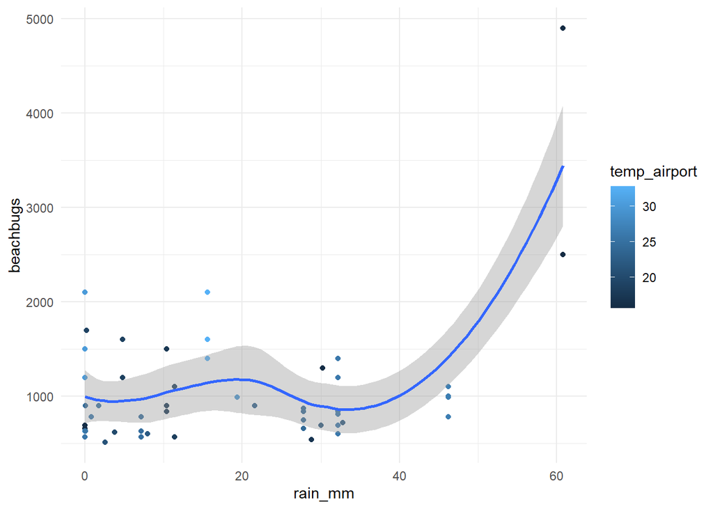

```r
raintemp %>%
  na.omit() %>%
  filter(beachbugs > 500) %>%
  ggplot(aes(x = rain_mm, y = beachbugs, color = temp_airport)) +
  geom_point() +
  geom_smooth()
```

# Themes, palettes, etc.

As you know by now, I set palettes in the second chunk of all of my coding files, just after my ‘library checkout’. I also used some theme tweaks in earlier plots so you saw that in action. You can also set theme_minimal early on using theme_set. I use theme_minimal because gridlines should be used in publications most of the time. theme_classic is good for some publication plots and is great for a lot of presentations to the public (not to scientists e.g. at conferences) if the differences you are discussing are large. Otherwise, gridlines help to highlight differences in the data. Remember that everything has a purpose.

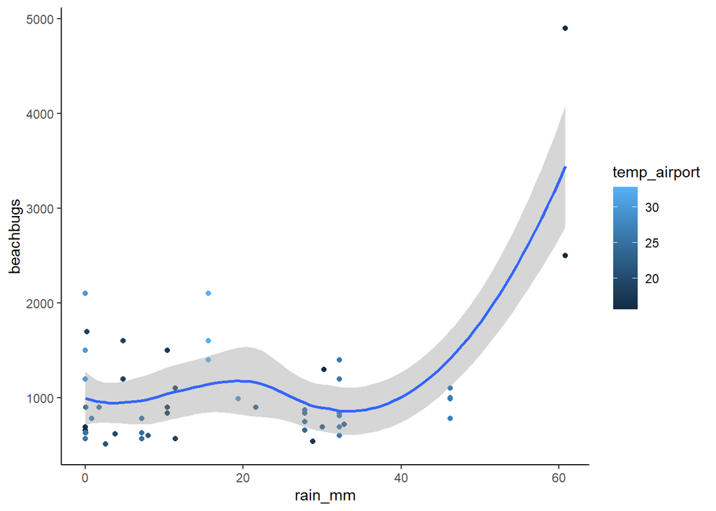

```r
raintemp %>%
  na.omit() %>%
  filter(beachbugs > 500) %>%
  ggplot(aes(x = rain_mm, y = beachbugs, color = temp_airport)) +
  geom_point() +
  geom_smooth() +
  theme_classic()  #play around
```

Since they give you examples of using RColorBrewer, I want to give you wesanderson examples.

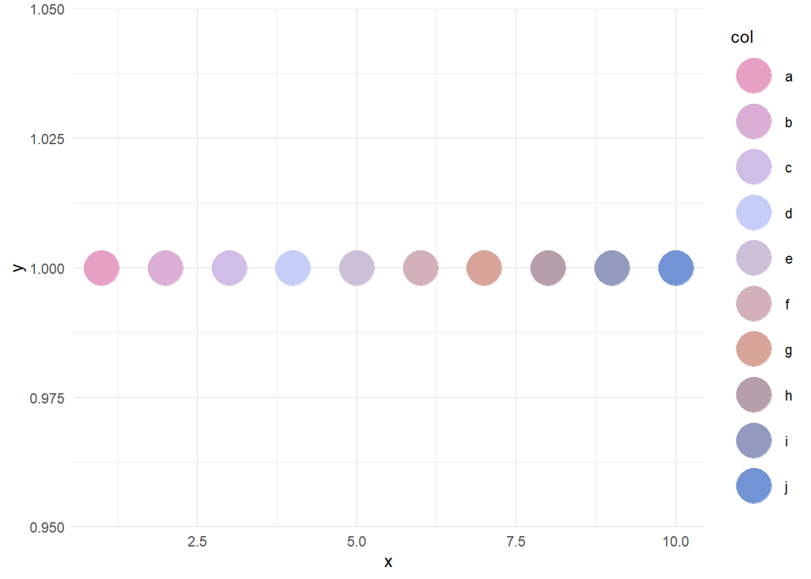

```r
grand_budapest2_palette <- wes_palette("GrandBudapest2", n = 10, type = "continuous") #this specifices which palette from the package, the number of colors (in this case 10), and that we need a continuous colour ramp as opposed to discrete

df <- data.frame(x=1:10, y=1, col=letters[1:10]) #create an empty dataframe

g <- ggplot(df, aes(x=x, y=y, color=col)) + geom_point(size=10) +
  scale_color_manual(values=wes_palette(10, name = "GrandBudapest2", type = "continuous")) #build a plot of the palette against your empty dataframe
g #view the colors
```

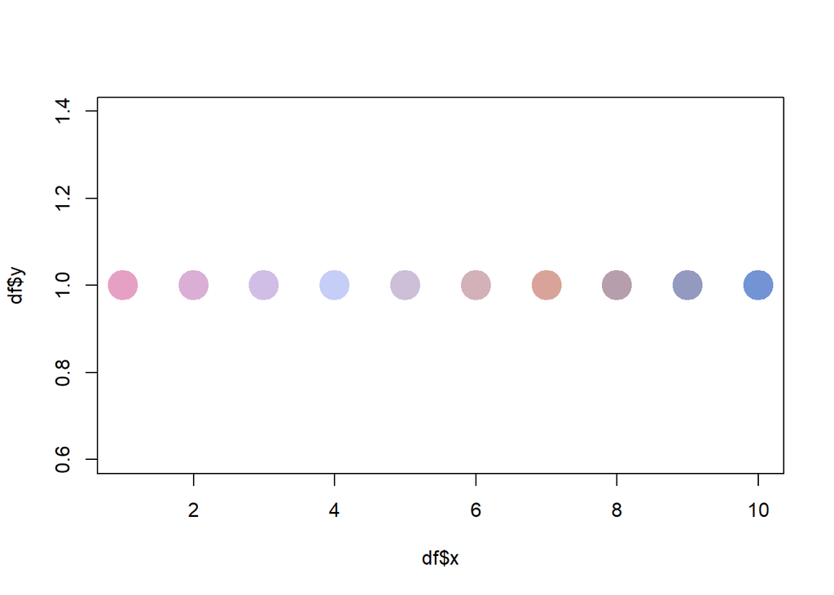

```r
#if you like them, proceed with the below steps to get the hex codes and then build the palette, calling hex codes to specific values in your actual datasets

colors <- ggplot_build(g)$data[[1]]$colour

plot(df$x, df$y, col=colors, pch=20, cex=5)
```

```r
colors[1:10]
```

```
##  [1] "#E6A0C4" "#DBAFD5" "#D0BEE6" "#C6CDF7" "#CCBFD7" "#D2B1B8" "#D8A499"
##  [8] "#B69EAC" "#9499C0" "#7294D4"
```

```r
unique(plotbeaches$site)
```

```
##  [1] "Clovelly Beach"            "Coogee Beach"
##  [3] "Gordons Bay (East)"        "Little Bay Beach"
##  [5] "Malabar Beach"             "Maroubra Beach"
##  [7] "South Maroubra Beach"      "South Maroubra \nRockpool"
##  [9] "Bondi Beach"               "Bronte Beach"
## [11] "Tamarama Beach"
```

```r
# Manually assign the hex codes to create a custom stretched palette
site_palette <- c(
  "Clovelly Beach" = "#7294D4",
  "Coogee Beach" = "#9499C0",
  "Bondi Beach" = "#C6CDF7",
  "Malabar Beach" = "#CCBFD7",
  "South Maroubra \nRockpool" = "#DBAFD5",
  "Bronte Beach" = "#E6A0C4"
)


print(site_palette)
```

```
##            Clovelly Beach              Coogee Beach               Bondi Beach
##                 "#7294D4"                 "#9499C0"                 "#C6CDF7"
##             Malabar Beach South Maroubra \nRockpool              Bronte Beach
##                 "#CCBFD7"                 "#DBAFD5"                 "#E6A0C4"
```

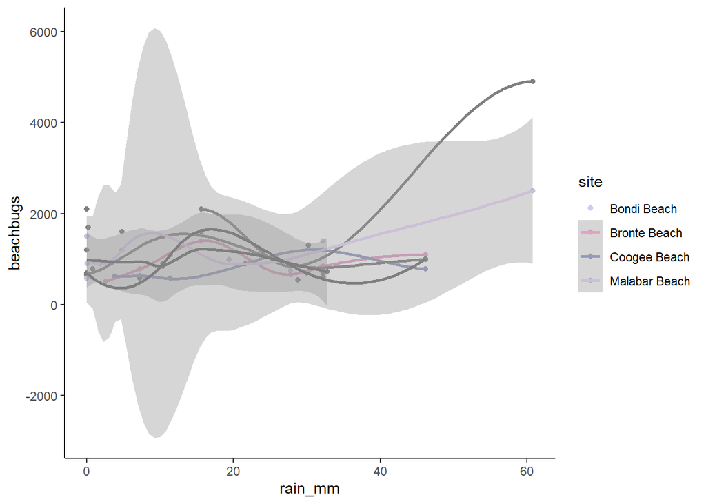

```r
raintemp %>%
  na.omit() %>%
  filter(beachbugs > 500) %>%
  ggplot(aes(x = rain_mm, y = beachbugs, color = site)) +
  scale_color_manual(values = site_palette) +
  geom_point() +
  geom_smooth() +
  theme_classic()  #play around
```